# IODS course project

Tatu Ylönen

This is a temporary project that exists only to complete mandatory classwork for the Open Data Science class at Helsinki University. I expect to hide or remove this repository after December 2020.

# Introduction to Open Data Science - Course Project

## Chapter 1: About the project

This repository is for an introductory open data science class for PhD students at University of Helsinki (with some students from other universities). The course is open to everyone, uses open source tools, and emphasizes open science. The statistics part seems fairly elementary, but I could use a brush-up and that is why I signed up for the course.

The course seems to cover github, R, Rstudio, linear and logistic regression, dimensionality reduction, clustering, hypothesis testing and some other basic multivariate statistical analysis tools.

Links to my repositories and web pages for the class:

- Github account: https://github.com/tatuylonen
- Github repository for this course: https://github.com/tatuylonen/IODS-project
- Github web page for the course diary: https://tatuylonen.github.io/IODS-project

## Chapter 2: Regression and model validation

### Data wrangling exercise

Here is code and output from data/create_learning2014.R:

```r
# Tatu Ylönen / University of Helsinki
# 1.11.2020
# RStudio Exercise 2 - data wrangling

# This uses the data set described in:
# Kimmo Vehkalahti: ASSIST 2014 - Phase 3 (end of Part 2), N=183
# Course: Johdatus yhteiskuntatilastotieteeseen, syksy 2014
# (Introduction to Social Statistics, fall 2014 - in Finnish),
# international survey of Approaches to Learning, made possible
# by Teachers' Academy funding for KV in 2013-2015.

library(dplyr)
# Load the data into a data frame.
data <- read.csv(file="http://www.helsinki.fi/~kvehkala/JYTmooc/JYTOPKYS3-data.txt", sep="\t")

# Print the dimensions of the data.
print("=== dimensions of the data JYTOPKYS3-data dataset")
```

```
## [1] "=== dimensions of the data JYTOPKYS3-data dataset"
```

```r
dim(data)
```

```
## [1] 183  60
```

```r
# Print a summary of what the data frame contains.
# Turns out there are 183 observations for 60 variables.
print("Structure of the JYTOPKYS3-data dataset")
```

```
## [1] "Structure of the JYTOPKYS3-data dataset"
```

```r
str(data)
```

```
## 'data.frame':    183 obs. of  60 variables:
##  $ Aa      : int  3 2 4 4 3 4 4 3 2 3 ...
##  $ Ab      : int  1 2 1 2 2 2 1 1 1 2 ...
##  $ Ac      : int  2 2 1 3 2 1 2 2 2 1 ...
##  $ Ad      : int  1 2 1 2 1 1 2 1 1 1 ...
##  $ Ae      : int  1 1 1 1 2 1 1 1 1 1 ...
##  $ Af      : int  1 1 1 1 1 1 1 1 1 2 ...
##  $ ST01    : int  4 4 3 3 4 4 5 4 4 4 ...
##  $ SU02    : int  2 2 1 3 2 3 2 2 1 2 ...
##  $ D03     : int  4 4 4 4 5 5 4 4 5 4 ...
##  $ ST04    : int  4 4 4 4 3 4 2 5 5 4 ...
##  $ SU05    : int  2 4 2 3 4 3 2 4 2 4 ...
##  $ D06     : int  4 2 3 4 4 5 3 3 4 4 ...
##  $ D07     : int  4 3 4 4 4 5 4 4 5 4 ...
##  $ SU08    : int  3 4 1 2 3 4 4 2 4 2 ...
```

[output cut: 46 more lines]

```r
# Create the analysis dataset with variables gender, age, attitude,
# deep, stra, surf and points.  First copy the data wrangling statements from
# the datacamp exercises.
data$attitude = data$Attitude / 10
deep_questions <- c("D03", "D11", "D19", "D27", "D07", "D14", "D22", "D30",
                    "D06",  "D15", "D23", "D31")
surface_questions <- c("SU02","SU10","SU18","SU26", "SU05","SU13","SU21",
                       "SU29","SU08","SU16","SU24","SU32")
strategic_questions <- c("ST01","ST09","ST17","ST25","ST04","ST12","ST20",
                         "ST28")
deep_columns <- select(data, one_of(deep_questions))
data$deep <- rowMeans(deep_columns)
surface_columns <- select(data, one_of(surface_questions))
data$surf <- rowMeans(surface_columns)
strategic_columns <- select(data, one_of(strategic_questions))
data$stra = rowMeans(strategic_columns)

# Select only the desired fields for the analysis data set
anal <- select(data, c("gender", "Age", "attitude", "deep", "stra", "surf",
                       "Points"))
colnames(anal)[2] <- "age"
colnames(anal)[7] <- "points"
# Exclude observations where the exam points variable is zero from the
# analysis data set
anal <- filter(anal, points != 0)

# Show the structure of the analysis dataset
print("=== analysis dataset")
```

```
## [1] "=== analysis dataset"
```

```r
str(anal)
```

```
## 'data.frame':    166 obs. of  7 variables:
##  $ gender  : Factor w/ 2 levels "F","M": 1 2 1 2 2 1 2 1 2 1 ...
##  $ age     : int  53 55 49 53 49 38 50 37 37 42 ...
##  $ attitude: num  3.7 3.1 2.5 3.5 3.7 3.8 3.5 2.9 3.8 2.1 ...
##  $ deep    : num  3.58 2.92 3.5 3.5 3.67 ...
##  $ stra    : num  3.38 2.75 3.62 3.12 3.62 ...
##  $ surf    : num  2.58 3.17 2.25 2.25 2.83 ...
##  $ points  : int  25 12 24 10 22 21 21 31 24 26 ...
```

```r
# Write the analysis data set into a file
write.csv(anal, "data/analysis-dataset.csv")

# Demonstrate that we can read back the analysis data set
readback <- read.csv("data/analysis-dataset.csv")
print("=== structure of the readback dataset")
```

```
## [1] "=== structure of the readback dataset"
```

```r
str(readback)
```

```
## 'data.frame':    166 obs. of  8 variables:
##  $ X       : int  1 2 3 4 5 6 7 8 9 10 ...
##  $ gender  : Factor w/ 2 levels "F","M": 1 2 1 2 2 1 2 1 2 1 ...
##  $ age     : int  53 55 49 53 49 38 50 37 37 42 ...
##  $ attitude: num  3.7 3.1 2.5 3.5 3.7 3.8 3.5 2.9 3.8 2.1 ...
##  $ deep    : num  3.58 2.92 3.5 3.5 3.67 ...
##  $ stra    : num  3.38 2.75 3.62 3.12 3.62 ...
##  $ surf    : num  2.58 3.17 2.25 2.25 2.83 ...
##  $ points  : int  25 12 24 10 22 21 21 31 24 26 ...
```

```r
print("=== head of the readback dataset")
```

```
## [1] "=== head of the readback dataset"
```

```r
head(readback)
```

```
##   X gender age attitude     deep  stra     surf points
## 1 1      F  53      3.7 3.583333 3.375 2.583333     25
## 2 2      M  55      3.1 2.916667 2.750 3.166667     12
## 3 3      F  49      2.5 3.500000 3.625 2.250000     24
## 4 4      M  53      3.5 3.500000 3.125 2.250000     10
## 5 5      M  49      3.7 3.666667 3.625 2.833333     22
## 6 6      F  38      3.8 4.750000 3.625 2.416667     21
```

### Analysis exercise

#### Objective of the study

The objective of the study was to analyze how various factors influence the student’s skills in statistics.

#### Methods

In this exercise we analyzed the dataset described in Kimmo Vehkalahti: The Relationship between Learning Approaches and Students’ Achievements in an Introductory Statistics Course in Finland, 60th World Statistics Congress (ISI2015), Rio de Janeiro, Brazil, July 2015. The overall approach is covered more deeply in Tait, Entwistle and McKune: ASSIST: The Approaches and Study Skills Inventory for Students, 1998.

The data set was collected to understand how various factors influence students’ statistics skills. It includes data for 183 students. A total of 60 variables were colleted. The variables can be grouped into those relating to the student’s background and scholastic achievements, deep questions (seeking meaning, relating ideas, use of evidence), surface questions (lack of purpose, unrelated memorizing, syllabus-boundedness), and strategic questions (organized studying, time management).

Student’s exam points are taken as measuring the level of the student’s skill that we try to explain using the other variables. For this analysis, we chose to use linear least squares regression using the student’s attitude and the averaged answers to surface questions and strategic questions as explanatory variables. We chose to not include deep questions, age, or gender as a possible explanatory variables because the assignment instructions said we should use three variables; extending the analysis to include additional variables would be straightforward.

We additionally analyze the significance of the results using the t statistic, including a look at the distribution of the regression errors and whether their distribution is approximately normal to verify that the significance testing methods chosen can be used in this situation.

The analysis was performed using R (version 3.6.3). The R scripts and their output are included below.

### Data preprocessing

The original data set can be found [here](http://www.helsinki.fi/~kvehkala/JYTmooc/JYTOPKYS3-data.txt) and its detailed description [here](https://www.mv.helsinki.fi/home/kvehkala/JYTmooc/JYTOPKYS3-meta.txt).

The data preprocessing was done using the script built for the data wrangling exercise, `data/create_learning2014.R`, shown above.

Observations where the exam points are zero were excluded from the analysis. This left 166 observations.

To get a quick overview of the data and the relationships between points and the possible explanatory variables, we first plot points against each variable.

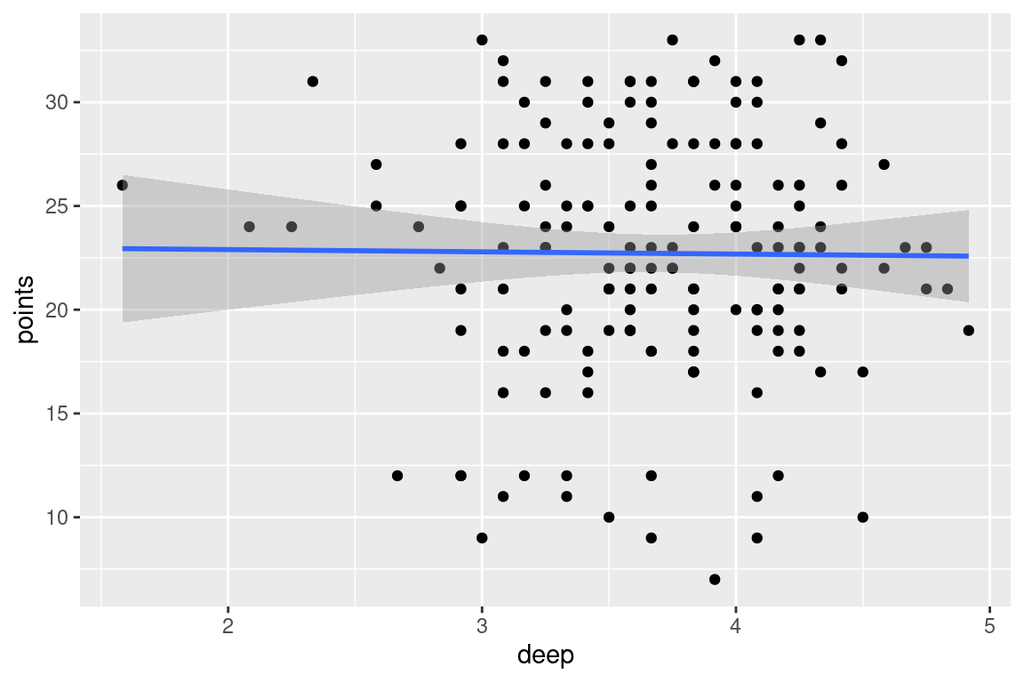

```r
library(ggplot2)
data <- read.csv("data/analysis-dataset.csv")
p <- ggplot(data, aes(x=deep, y=points)) + geom_point() + geom_smooth(method=lm)
p
```

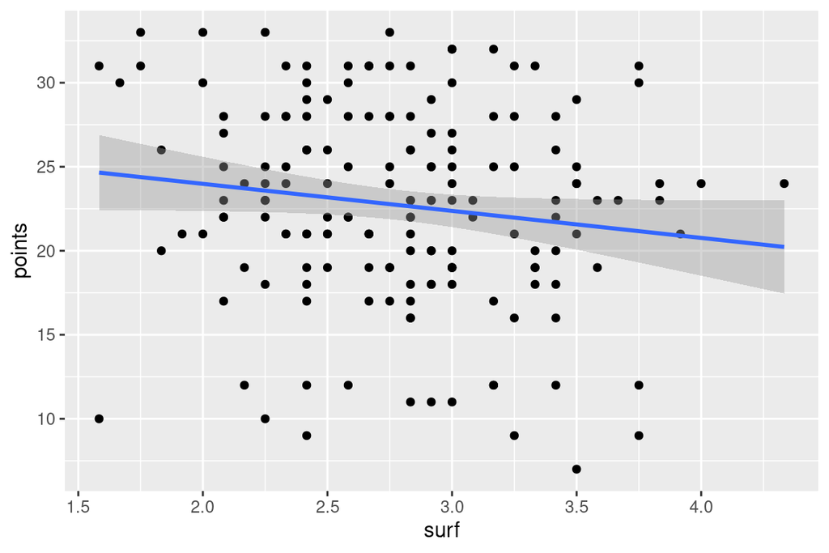

```r
p <- ggplot(data, aes(x=surf, y=points)) + geom_point() + geom_smooth(method=lm)
p
```

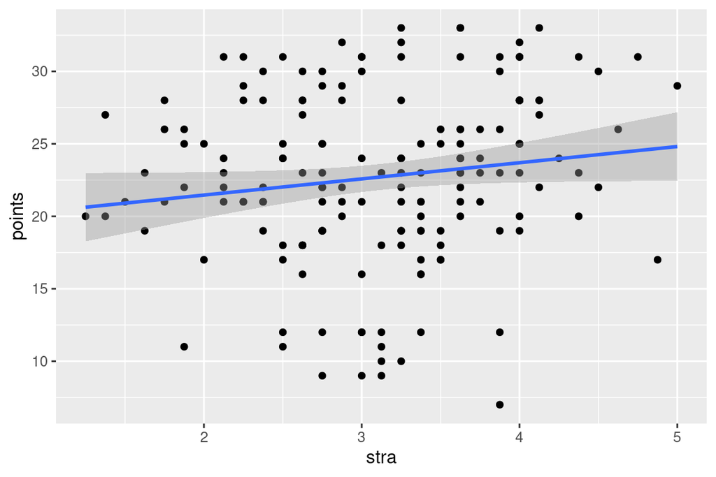

```r
p <- ggplot(data, aes(x=stra, y=points)) + geom_point() + geom_smooth(method=lm)
p
```

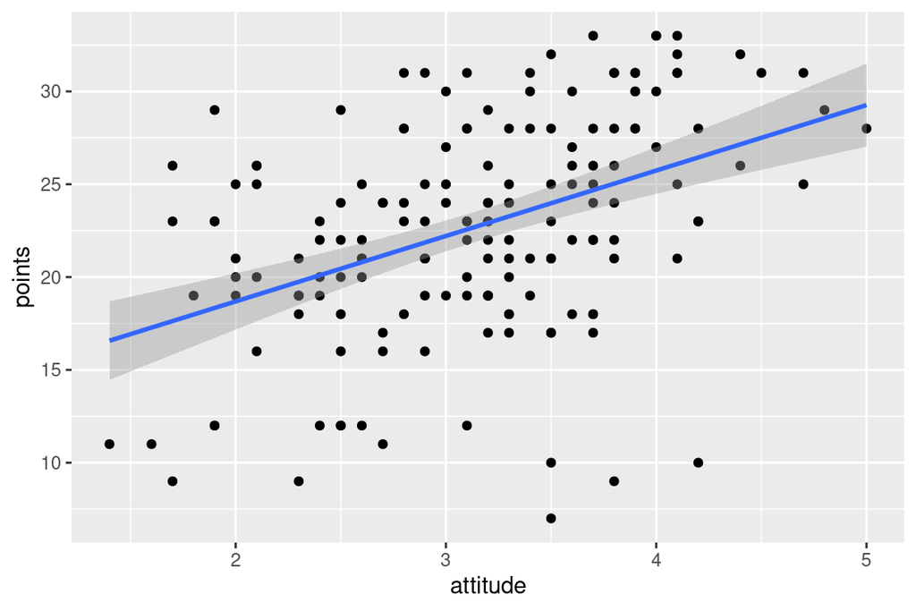

```r
p <- ggplot(data, aes(x=attitude, y=points)) + geom_point() + geom_smooth(method=lm)
p
```

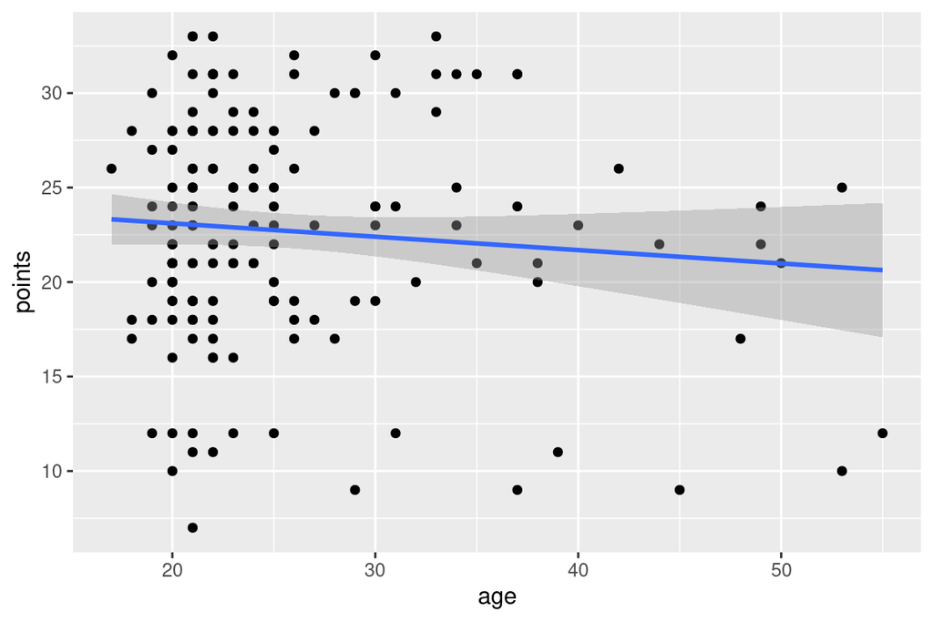

```r
p <- ggplot(data, aes(x=age, y=points)) + geom_point() + geom_smooth(method=lm)
p
```

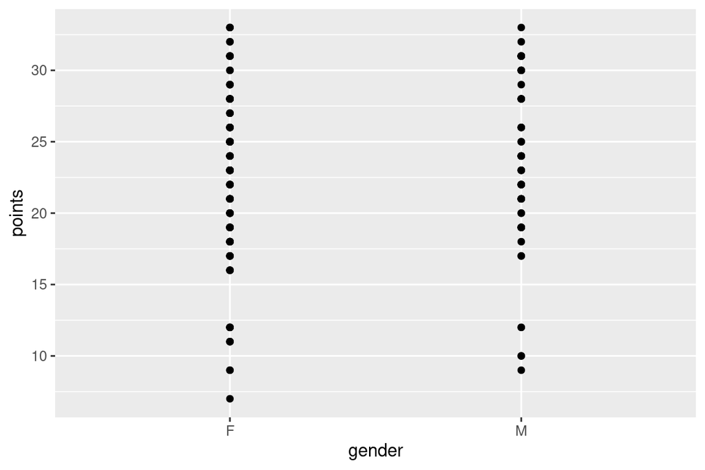

```r
p <- ggplot(data, aes(x=gender, y=points)) + geom_point() + geom_smooth(method=lm)
p
```

It is clear that gender as a two-category variable is not suitable for linear regression. The data also contains relatively few observations for age above about 27, so it is probably not a very helpful explanatory variable either. Also the deep questions have most averages concentrated between 3 and 5, so it might be less useful for regression than the other variables; it also seems to have little influence on points based on the regression line. These observations contributed to choosing attitude, surf, and stra for our analysis.

#### Analysis

First, we compute a linear least squares regression, trying to explain points using the students’ attitude and the averaged answers for the surface and strategic questions.

```r
library(dplyr)
data <- read.csv("data/analysis-dataset.csv")
model <- lm(points ~ attitude + surf + stra, data=data)
summary(model)
```

```
##
## Call:
## lm(formula = points ~ attitude + surf + stra, data = data)
##
## Residuals:
##      Min       1Q   Median       3Q      Max
## -17.1550  -3.4346   0.5156   3.6401  10.8952
##
## Coefficients:
##             Estimate Std. Error t value Pr(>|t|)
## (Intercept)  11.0171     3.6837   2.991  0.00322 **
## attitude      3.3952     0.5741   5.913 1.93e-08 ***
## surf         -0.5861     0.8014  -0.731  0.46563
## stra          0.8531     0.5416   1.575  0.11716
## ---
## Signif. codes:  0 '***' 0.001 '**' 0.01 '*' 0.05 '.' 0.1 ' ' 1
##
## Residual standard error: 5.296 on 162 degrees of freedom
## Multiple R-squared:  0.2074, Adjusted R-squared:  0.1927
## F-statistic: 14.13 on 3 and 162 DF,  p-value: 3.156e-08
```

The t statistic used for significance testing in this linear regression assumes that the distribution of errors follows the normal distribution. To validate this assumption, we first plot the residuals.

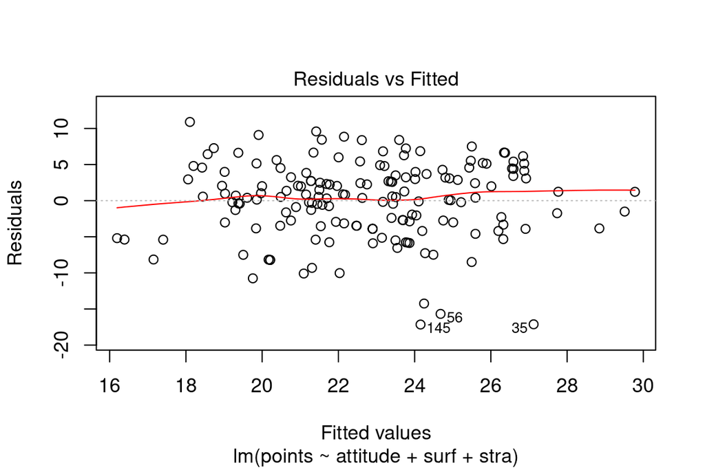

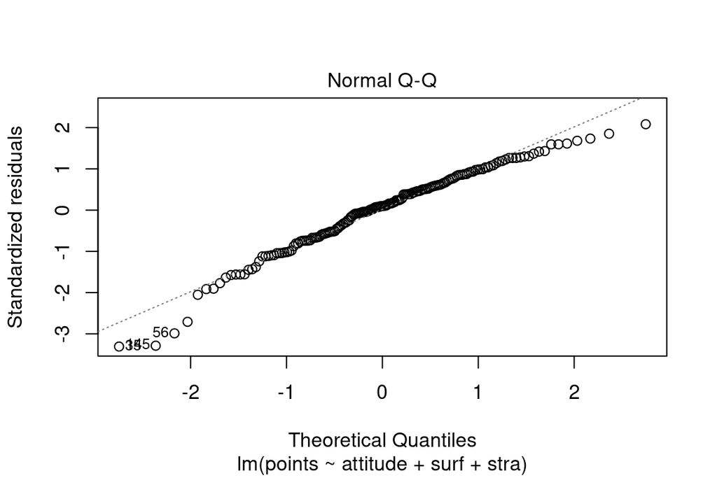

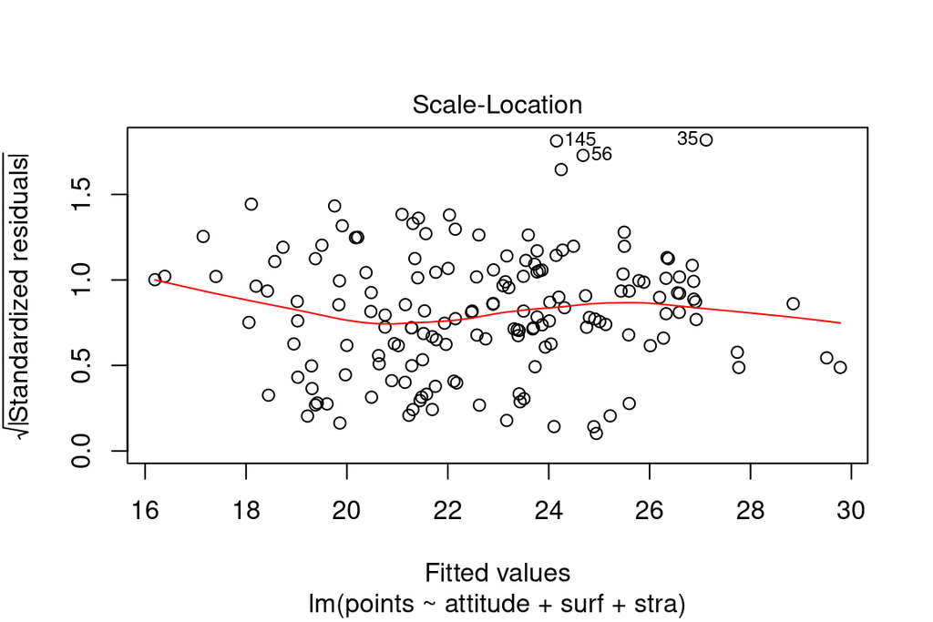

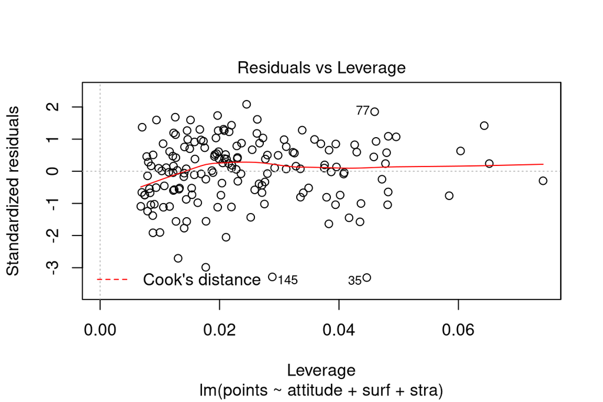

```r
library(dplyr)
data <- read.csv("data/analysis-dataset.csv")
model <- lm(points ~ attitude + surf + stra, data=data)
plot(model)
```

The residuals vs. fitted plot shows no obvious pattern that would invalidate the p values. For a normal distribution we would expect the highest concentration of residuals around zero and the residuals should be independent of the fitted value. There is a small cluster of negative residuals near 24-27 and at extreme fitted values the residuals tend to be negative. However this effect seems small enough to not cause significant concern.

From the Q-Q plot we would expect residual distribution to match the theoretical distribution. we can see that while the regression seems to work fairly well for most data points, extreme errors on both sides tend to be more negative than predicted by a normal distribution. However the deviation is not very big. Overall, the plot looks to me as sufficiently consistent with a bounded normal distribution to consider the p values reasonably reliable, but some caution woul be warranted.

Finally, the residuals vs. leverage plot for a normal distribution should show the same spread regardless of leverage and the standardized residual density should follow a normal distribution. This appears to hold reasonably well in this case, though it is also possible that the spread decreases with leverage. There are too few data points at high leverage to be sure. Generally I would say the plot is consistent with the assumption of an approximately normal distribution of residuals.

We will now remove the variables that are not statistically significant from the regression. Thus, we compute the regression against just attitude.

```r
library(dplyr)
data <- read.csv("data/analysis-dataset.csv")
model <- lm(points ~ attitude, data=data)
summary(model)
```

```
##
## Call:
## lm(formula = points ~ attitude, data = data)
##
## Residuals:
##      Min       1Q   Median       3Q      Max
## -16.9763  -3.2119   0.4339   4.1534  10.6645
##
## Coefficients:
##             Estimate Std. Error t value Pr(>|t|)
## (Intercept)  11.6372     1.8303   6.358 1.95e-09 ***
## attitude      3.5255     0.5674   6.214 4.12e-09 ***
## ---
## Signif. codes:  0 '***' 0.001 '**' 0.01 '*' 0.05 '.' 0.1 ' ' 1
##
## Residual standard error: 5.32 on 164 degrees of freedom
## Multiple R-squared:  0.1906, Adjusted R-squared:  0.1856
## F-statistic: 38.61 on 1 and 164 DF,  p-value: 4.119e-09
```

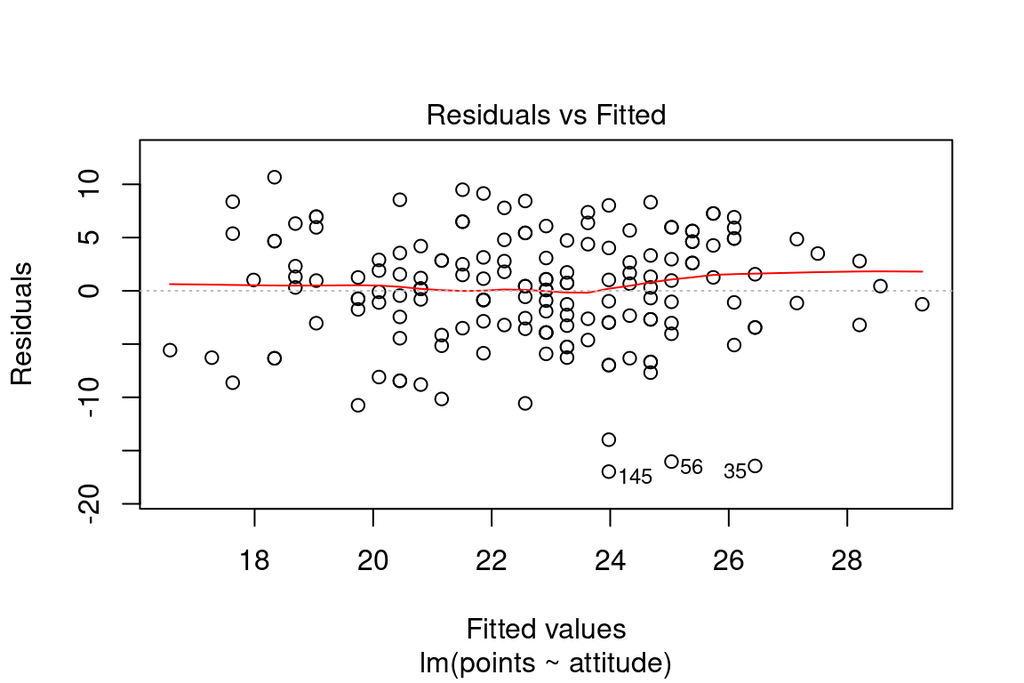

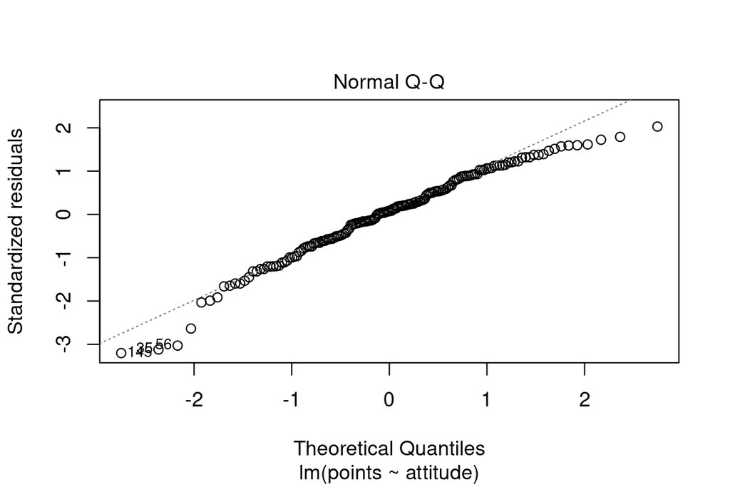

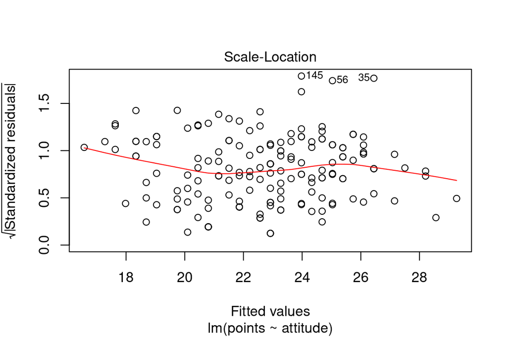

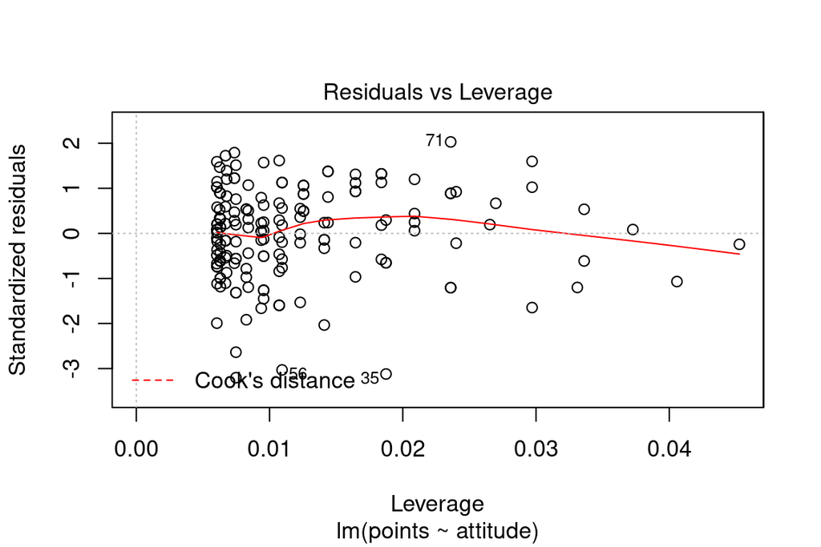

```r
plot(model)
```

Looking at the residuals vs fitted plot, it now looks like a better match against the normal distribution, though there seem to be fewer than expected samples further out. The Q-Q plot has not changed much, or perhaps the negative deviation at extremes has gotten stronger.

Given the very high significance from the t test and the approximate conformance with the normal distribution, it seems likely that the result for attitude truly is significant. However, I would not trust the absolute p value as there is some deviation from a normal distribution. I would seek to confirm the p value using nonparametric tests if submitting for a peer-reviewed scientific publication.

Finally, we try to analyze the correlation and explanatory power of attitude on points. For this, we use the Pearson correlation coefficient and use R<sup>2</sup> to measure explanatory power. This assumes a normal distribution.

```r
library(dplyr)
data <- read.csv("data/analysis-dataset.csv")
r = cor(data$attitude, data$points, method="pearson")
print(r)
```

```
## [1] 0.4365245
```

```r
print(cat("correlation R", r, "\n"))
```

```
## correlation R 0.4365245
## NULL
```

```r
print(cat("R^2", r * r, "\n"))
```

```
## R^2 0.1905537
## NULL
```

The R<sup>2</sup> value of 0.19 suggests that attitude explains about 19% of the variance in points.

#### Conclusion

The student’s attitude toward statistics seems to have a statistically significant relationship with the student’s points on the exam that can be approximated with a linear model:
$$points = 3.53 \cdot attitude + 11.64$$

This model explains about 19% of the variance in points. About 81% of variance is not explained by this model.

It should be noted that we have not analyzed whether higher points are caused by attitude or vice versa, or if the results could be better explained by some other common couse. We have merely detected a correlation.

## Chapter 3: Logistic regression

### Data wrangling

See the script `create_alc.R` in the [data directory on github](https://github.com/tatuylonen/IODS-project/tree/master/data).

### Analysis

In this exercise we analyzed how students’ alcohol usage can be predicted using other variables in the data set. The data set is the [Student Performance Data Set](https://archive.ics.uci.edu/ml/datasets/Student+Performance) from the Machine Learning Repository at UC Irwine. The dataset is described in P. Cortez and A. Silva: Using Data Mining to Predict Secondary School Student Performance. In A. Brito and J. Teixeira (eds): Proceedings of 5th FUture BUsiness TEChnology Conference (FUBUTEC 2008), pp. 5-12, Porto, Portugal, April 2008.

#### (2) Loading data and describing it

First, let’s look at an overview of the data. Looking at available field names, we select a few fields as potential candidates for further investigation.

```r
library(dplyr)
library(GGally)
```

```r
library(ggplot2)

alc <- read.csv("http://s3.amazonaws.com/assets.datacamp.com/production/course_2218/datasets/alc.txt")

# Print column names
colnames(alc)
```

```
##  [1] "school"     "sex"        "age"        "address"    "famsize"
##  [6] "Pstatus"    "Medu"       "Fedu"       "Mjob"       "Fjob"
## [11] "reason"     "nursery"    "internet"   "guardian"   "traveltime"
## [16] "studytime"  "failures"   "schoolsup"  "famsup"     "paid"
## [21] "activities" "higher"     "romantic"   "famrel"     "freetime"
## [26] "goout"      "Dalc"       "Walc"       "health"     "absences"
## [31] "G1"         "G2"         "G3"         "alc_use"    "high_use"
```

```r
# Print overall structure of the data
str(alc)
```

```
## 'data.frame':    382 obs. of  35 variables:
##  $ school    : Factor w/ 2 levels "GP","MS": 1 1 1 1 1 1 1 1 1 1 ...
##  $ sex       : Factor w/ 2 levels "F","M": 1 1 1 1 1 2 2 1 2 2 ...
##  $ age       : int  18 17 15 15 16 16 16 17 15 15 ...
##  $ address   : Factor w/ 2 levels "R","U": 2 2 2 2 2 2 2 2 2 2 ...
##  $ famsize   : Factor w/ 2 levels "GT3","LE3": 1 1 2 1 1 2 2 1 2 1 ...
##  $ Pstatus   : Factor w/ 2 levels "A","T": 1 2 2 2 2 2 2 1 1 2 ...
##  $ Medu      : int  4 1 1 4 3 4 2 4 3 3 ...
##  $ Fedu      : int  4 1 1 2 3 3 2 4 2 4 ...
##  $ Mjob      : Factor w/ 5 levels "at_home","health",..: 1 1 1 2 3 4 3 3 4 3 ...
##  $ Fjob      : Factor w/ 5 levels "at_home","health",..: 5 3 3 4 3 3 3 5 3 3 ...
##  $ reason    : Factor w/ 4 levels "course","home",..: 1 1 3 2 2 4 2 2 2 2 ...
##  $ nursery   : Factor w/ 2 levels "no","yes": 2 1 2 2 2 2 2 2 2 2 ...
##  $ internet  : Factor w/ 2 levels "no","yes": 1 2 2 2 1 2 2 1 2 2 ...
##  $ guardian  : Factor w/ 3 levels "father","mother",..: 2 1 2 2 1 2 2 2 2 2 ...
```

[output cut: 21 more lines]

The data includes numerous factors describing the the student’s background and lifestyle, as well problems with the student’s studies, such as failed classes or absences, and the student’s alcohol usage. Our task is to study the relationship between high/low alcohol consumption and the other data. In total, the data set includes 382 observations for 35 variables.

#### (3) Selecting four variables and hypotheses

Looking at the data, I decided to choose the following variables for closer inspection:

- Medu (Mother’s education) - it is conceivable parent’s education could have an influence (generally higher education of parents correlates with school success, I think)
- Fedu (Father’s education) - same reason
- goout (How much goes out with friends - people often drink when they go out)
- famrel (Quality of family relationships) - conceivably this could have an influence, for example kids of problem families having more problems of their own (i.e., negative correlation in this case).

#### (4) Graphical and numerical analysis of the variables

Let’s now look at them graphically using scatterplots (with some position jitter to make the point density more visible, given the discrete valus):

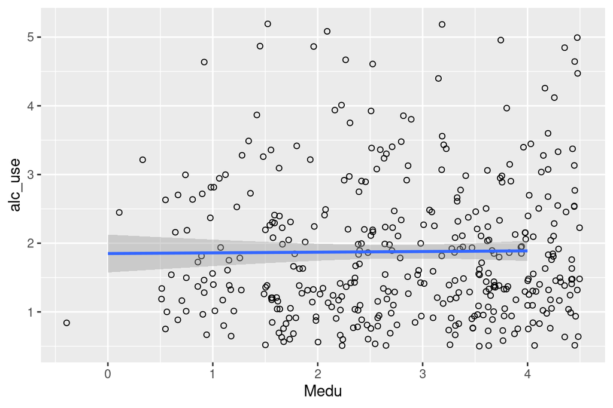

```r
ggplot(alc, aes(x=Medu, y=alc_use)) + geom_point(shape=1, position=position_jitter(width=0.5, height=0.5)) + geom_smooth(method=lm)
```

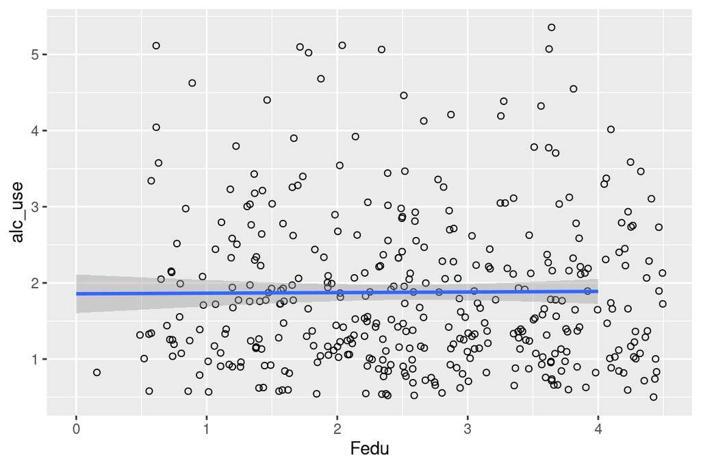

```r
ggplot(alc, aes(x=Fedu, y=alc_use)) + geom_point(shape=1, position=position_jitter(width=0.5, height=0.5)) + geom_smooth(method=lm)
```

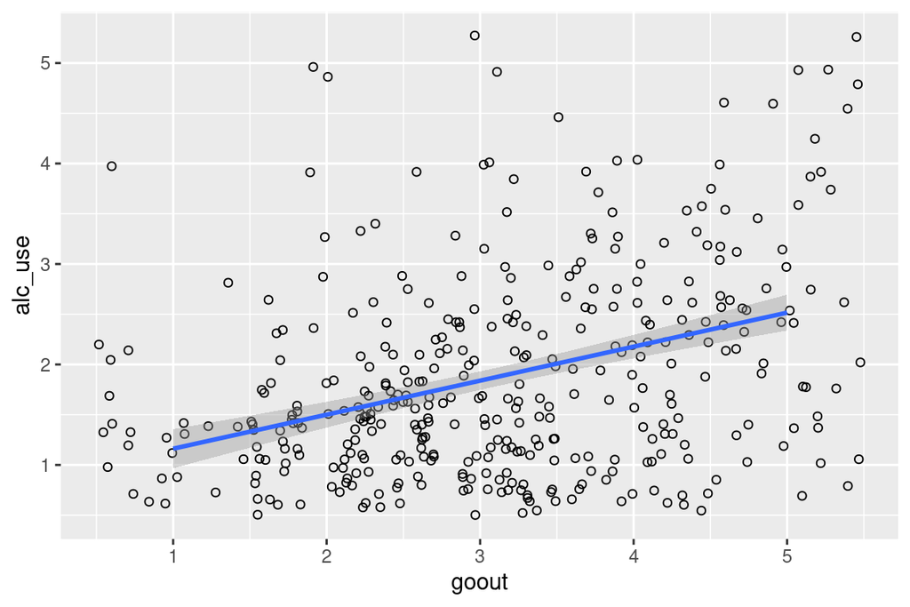

```r
ggplot(alc, aes(x=goout, y=alc_use)) + geom_point(shape=1, position=position_jitter(width=0.5, height=0.5)) + geom_smooth(method=lm)
```

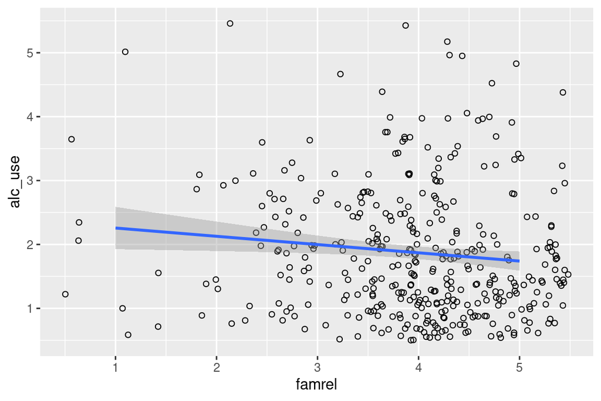

```r
ggplot(alc, aes(x=famrel, y=alc_use)) + geom_point(shape=1, position=position_jitter(width=0.5, height=0.5)) + geom_smooth(method=lm)
```

Let’s also look at the data numerically using covariances.

```r
# Covariances help us understand the relationship between different variables.
sub <- select(alc, one_of(c("alc_use", "Medu", "Fedu", "goout", "famrel")))
cov(sub, sub)
```

```
##              alc_use       Medu        Fedu      goout      famrel
## alc_use  0.975635899 0.01153619 0.009385607 0.43383353 -0.10978961
## Medu     0.011536189 1.18022289 0.773865963 0.08223056  0.01192783
## Fedu     0.009385607 0.77386596 1.201742452 0.04117025  0.01313710
## goout    0.433833533 0.08223056 0.041170246 1.28125902  0.08291077
## famrel  -0.109789614 0.01192783 0.013137101 0.08291077  0.84938368
```

We can see that alc_use has a covariance of 0.43 with `goout` and `-0.11` with famrel, while the covariances with `Medu` and `Fedu` are small.

Visually and based on the linear regression line, it does not look like parents’ education has much impact on alcohol use. Nevertheless, they might have an impact when conditioning on other variables or after eliminating the impact of other variables, so let’s keep them in the analysis. Going out and family relationships, however, show a clear impact.

#### (5) Logistic regression

```r
library(boot)

m <- glm(high_use ~ Medu + Fedu + goout + famrel, data=alc, family="binomial")
summary(m)
```

```
##
## Call:
## glm(formula = high_use ~ Medu + Fedu + goout + famrel, family = "binomial",
##     data = alc)
##
## Deviance Residuals:
##     Min       1Q   Median       3Q      Max
## -1.6349  -0.7725  -0.5598   0.9912   2.4030
##
## Coefficients:
##             Estimate Std. Error z value Pr(>|z|)
## (Intercept) -1.73933    0.68188  -2.551  0.01075 *
## Medu        -0.10465    0.14883  -0.703  0.48194
## Fedu         0.05742    0.14751   0.389  0.69707
## goout        0.80690    0.11928   6.765 1.33e-11 ***
## famrel      -0.42459    0.13316  -3.189  0.00143 **
## ---
## Signif. codes:  0 '***' 0.001 '**' 0.01 '*' 0.05 '.' 0.1 ' ' 1
##
## (Dispersion parameter for binomial family taken to be 1)
##
##     Null deviance: 462.21  on 381  degrees of freedom
## Residual deviance: 401.82  on 377  degrees of freedom
## AIC: 411.82
##
## Number of Fisher Scoring iterations: 4
```

Looking at the significance level of the coefficients, we can see that `Medu` and `Fedu` are not statistically significant, while `goout` and `famrel` are statistically significant at the p=0.01 level. Let’s run the regression again but without `Medu` and `Fedu`.

```r
library(boot)

m <- glm(high_use ~ goout + famrel, data=alc, family="binomial")
summary(m)
```

```
##
## Call:
## glm(formula = high_use ~ goout + famrel, family = "binomial",
##     data = alc)
##
## Deviance Residuals:
##     Min       1Q   Median       3Q      Max
## -1.5586  -0.7385  -0.5676   0.9969   2.3758
##
## Coefficients:
##             Estimate Std. Error z value Pr(>|z|)
## (Intercept)  -1.8742     0.6015  -3.116  0.00183 **
## goout         0.8004     0.1187   6.743 1.55e-11 ***
## famrel       -0.4218     0.1330  -3.171  0.00152 **
## ---
## Signif. codes:  0 '***' 0.001 '**' 0.01 '*' 0.05 '.' 0.1 ' ' 1
##
## (Dispersion parameter for binomial family taken to be 1)
##
##     Null deviance: 462.21  on 381  degrees of freedom
## Residual deviance: 402.32  on 379  degrees of freedom
## AIC: 408.32
##
## Number of Fisher Scoring iterations: 4
```

We can see that `goout` and `famrel` are still statistically significant at the p=0.01 level, with coefficients of 0.80 and -0.42, respectively. Their standard errors are at most of 1/3 of the absolute value of the means.

Let’s now look at the coefficients and their confidence intervals after exponentiation. Exponentiation effectively coverts addition into multiplication, and coefficients >1 indicate positive impact on `high_use` while coefficients <1 indicate negative impact on `high_use`.

```r
OR <- coef(m) %>% exp
OR
```

```
## (Intercept)       goout      famrel
##   0.1534844   2.2264964   0.6558574
```

```r
CI <- exp(confint(m))
CI
```

```
##                  2.5 %    97.5 %
## (Intercept) 0.04577266 0.4877710
## goout       1.77580201 2.8309109
## famrel      0.50355350 0.8498297
```

```r
cbind(OR, CI)
```

```
##                    OR      2.5 %    97.5 %
## (Intercept) 0.1534844 0.04577266 0.4877710
## goout       2.2264964 1.77580201 2.8309109
## famrel      0.6558574 0.50355350 0.8498297
```

We can see that the results are in line with our hypothesis and the results we got with non-exponentiated coefficients (i.e., negative value there corresponds to a value <1 in after exponentiation).

The exponentiated coefficients relate directly to the odds ratios. Essentially, in this case, an increase in `goout` by increases the odds by a factor of 2.2, and an increase in `famrel` decreases the odds by a factor of 0.66. The confidence intervals of these odds ratios are given directly by the confidence intervals for the exponentiated coefficients as reported by `exp(confint(m))` above.

#### (6) Predictive power and cross tabulation

Let’s now explore the predictive power of the model.

```r
loss_func <- function(class, prob) {
  n_wrong <- abs(class - prob) > 0.5
  mean(n_wrong)
}

# Predict the probability of high_use using the model
probabilities <- predict(m, type="response")
alc <- mutate(alc, probability=probabilities)
alc <- mutate(alc, prediction=probability >= 0.5)

# Let's look at ten samples and how they were predicted vs. actual high_use
select(alc, high_use, prediction, Medu, Fedu, goout, famrel) %>% tail(10)
```

```
##     high_use prediction Medu Fedu goout famrel
## 373    FALSE      FALSE    1    1     2      4
## 374     TRUE      FALSE    4    2     3      5
## 375    FALSE      FALSE    2    2     3      5
## 376    FALSE      FALSE    4    4     3      4
## 377    FALSE      FALSE    2    3     2      5
## 378    FALSE      FALSE    3    1     4      4
## 379    FALSE      FALSE    1    1     1      1
## 380    FALSE      FALSE    1    1     1      1
## 381     TRUE       TRUE    3    1     5      2
## 382     TRUE      FALSE    3    2     1      4
```

```r
# Let's also create the confusion matrix for the prediction
table(high_use=alc$high_use, prediction=alc$prediction)
```

```
##         prediction
## high_use FALSE TRUE
##    FALSE   243   27
##    TRUE     64   48
```

Let’s also look at a scatterplot of the predictions vs. actual values (though this is not very useful as we only have four possible combinations of values - but a plot with position jitter will slow something).

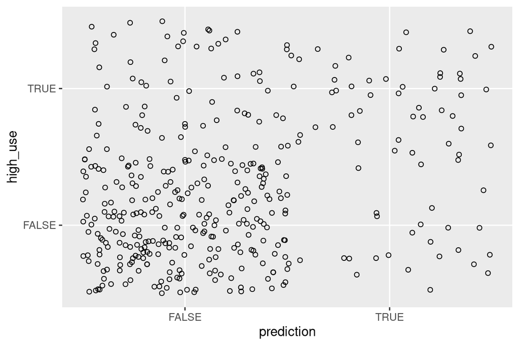

```r
ggplot(alc, aes(x=prediction, y=high_use)) + geom_point(shape=1, position=position_jitter(width=0.5, height=0.5))
```

The plot supports our earlier analysis of the confusion matrics.

#### (7) Cross-validation

Let’s now use 10-fold cross-validation to estimate how sensitive the model is to sampling of the data. (Loss function was already defined above)

```r
cv <- cv.glm(data=alc, cost=loss_func, glmfit = m, K = 10)

# average number of wrong predictions in the cross validation, e.g., error
cv$delta[1]
```

```
## [1] 0.2617801
```

#### (8) Comparing different models using cross-validation

Let’s now see how the model error behaves as the number of variables decreases. For this analysis we’ll first use all variables (except `high_use`, `alc_use`, `Dalc`, `Walc`, `probability`, and `prediction`) as explanatory variables, and then start removing variables that have low significance. Finally, we will collect the cross-validation errors and plot the change in error as a function of the number of variables removed. We’ll use 29-fold cross-validation to reduce the estimation error while keeping running times reasonable (R warns about K=30; using 29 instead reduces garbage in this report).

```r
# These columns are always excluded
always_exclude = c("high_use", "alc_use", "Dalc", "Walc",
  "prediction", "probability")

# Dataframe where we collect the errors from each step in simplification
# (this is updated by the step() function)
results = data.frame(count=integer(), error=double(), last=character())

# Estimate a model that excludes the variables given as argument (plus the
# variables that are always excluded), performs cross-validation to estimate
# the model error, and collects the errors into ``results``.
step <- function(additional_excludes) {
  excludes <- c(always_exclude, additional_excludes)
  cols <- colnames(alc)[!colnames(alc) %in% excludes]
  formula_text <- paste("high_use ~ ", paste(cols, collapse=" + "))
  formula = as.formula(formula_text)
  m <- glm(formula, data=alc)
  probabilities <- predict(m, type="response")
  alc <- mutate(alc, probability=probabilities)
  alc <- mutate(alc, prediction=probability >= 0.5)
  cv <- cv.glm(data=alc, cost=loss_func, glmfit=m, K=29)
  error <- cv$delta[1]  # error
  count <- length(additional_excludes)
  if (length(additional_excludes) == 0) {
    last = "<none>"
  } else {
    last <- additional_excludes[[length(additional_excludes)]]
  }
  results <<- rbind(results, data.frame(count, error, last))
  return(m)
}

# Perform one step for the exercise.  We can add steps by adding more fields
# to be excluded (as many as we like).
m <- step(c())  # famsup has lowest significance
m <- step(c("famsup"))
m <- step(c("famsup", "schoolsup"))
m <- step(c("famsup", "schoolsup", "traveltime"))
m <- step(c("famsup", "schoolsup", "traveltime", "Fjob"))
m <- step(c("famsup", "schoolsup", "traveltime", "Fjob", "Fedu"))
m <- step(c("famsup", "schoolsup", "traveltime", "Fjob", "Fedu",
  "Fjob"))
m <- step(c("famsup", "schoolsup", "traveltime", "Fjob", "Fedu",
  "Fjob", "famsize"))
m <- step(c("famsup", "schoolsup", "traveltime", "Fjob", "Fedu",
  "Fjob", "famsize", "G2"))
m <- step(c("famsup", "schoolsup", "traveltime", "Fjob", "Fedu",
  "Fjob", "famsize", "G2", "failures"))
m <- step(c("famsup", "schoolsup", "traveltime", "Fjob", "Fedu",
  "Fjob", "famsize", "G2", "failures", "internet"))
m <- step(c("famsup", "schoolsup", "traveltime", "Fjob", "Fedu",
  "Fjob", "famsize", "G2", "failures", "internet", "G1"))
m <- step(c("famsup", "schoolsup", "traveltime", "Fjob", "Fedu",
  "Fjob", "famsize", "G2", "failures", "internet", "G1", "G3"))
m <- step(c("famsup", "schoolsup", "traveltime", "Fjob", "Fedu",
  "Fjob", "famsize", "G2", "failures", "internet", "G1", "G3", "studytime"))
m <- step(c("famsup", "schoolsup", "traveltime", "Fjob", "Fedu",
  "Fjob", "famsize", "G2", "failures", "internet", "G1", "G3", "studytime",
  "activities"))
m <- step(c("famsup", "schoolsup", "traveltime", "Fjob", "Fedu",
  "Fjob", "famsize", "G2", "failures", "internet", "G1", "G3", "studytime",
  "activities", "school"))
m <- step(c("famsup", "schoolsup", "traveltime", "Fjob", "Fedu",
  "Fjob", "famsize", "G2", "failures", "internet", "G1", "G3", "studytime",
  "activities", "school", "health"))
m <- step(c("famsup", "schoolsup", "traveltime", "Fjob", "Fedu",
  "Fjob", "famsize", "G2", "failures", "internet", "G1", "G3", "studytime",
  "activities", "school", "health", "Mjob"))
m <- step(c("famsup", "schoolsup", "traveltime", "Fjob", "Fedu",
  "Fjob", "famsize", "G2", "failures", "internet", "G1", "G3", "studytime",
  "activities", "school", "health", "Mjob", "Medu"))
m <- step(c("famsup", "schoolsup", "traveltime", "Fjob", "Fedu",
  "Fjob", "famsize", "G2", "failures", "internet", "G1", "G3", "studytime",
  "activities", "school", "health", "Mjob", "Medu", "freetime"))
m <- step(c("famsup", "schoolsup", "traveltime", "Fjob", "Fedu",
  "Fjob", "famsize", "G2", "failures", "internet", "G1", "G3", "studytime",
  "activities", "school", "health", "Mjob", "Medu", "freetime", "reason"))
m <- step(c("famsup", "schoolsup", "traveltime", "Fjob", "Fedu",
  "Fjob", "famsize", "G2", "failures", "internet", "G1", "G3", "studytime",
  "activities", "school", "health", "Mjob", "Medu", "freetime", "reason",
  "Pstatus"))
m <- step(c("famsup", "schoolsup", "traveltime", "Fjob", "Fedu",
  "Fjob", "famsize", "G2", "failures", "internet", "G1", "G3", "studytime",
  "activities", "school", "health", "Mjob", "Medu", "freetime", "reason",
  "Pstatus", "address"))
m <- step(c("famsup", "schoolsup", "traveltime", "Fjob", "Fedu",
  "Fjob", "famsize", "G2", "failures", "internet", "G1", "G3", "studytime",
  "activities", "school", "health", "Mjob", "Medu", "freetime", "reason",
  "Pstatus", "address", "age"))
m <- step(c("famsup", "schoolsup", "traveltime", "Fjob", "Fedu",
  "Fjob", "famsize", "G2", "failures", "internet", "G1", "G3", "studytime",
  "activities", "school", "health", "Mjob", "Medu", "freetime", "reason",
  "Pstatus", "address", "age", "guardian"))
m <- step(c("famsup", "schoolsup", "traveltime", "Fjob", "Fedu",
  "Fjob", "famsize", "G2", "failures", "internet", "G1", "G3", "studytime",
  "activities", "school", "health", "Mjob", "Medu", "freetime", "reason",
  "Pstatus", "address", "age", "guardian", "romantic"))
m <- step(c("famsup", "schoolsup", "traveltime", "Fjob", "Fedu",
  "Fjob", "famsize", "G2", "failures", "internet", "G1", "G3", "studytime",
  "activities", "school", "health", "Mjob", "Medu", "freetime", "reason",
  "Pstatus", "address", "age", "guardian", "romantic", "higher"))
m <- step(c("famsup", "schoolsup", "traveltime", "Fjob", "Fedu",
  "Fjob", "famsize", "G2", "failures", "internet", "G1", "G3", "studytime",
  "activities", "school", "health", "Mjob", "Medu", "freetime", "reason",
  "Pstatus", "address", "age", "guardian", "romantic", "higher", "paid"))
m <- step(c("famsup", "schoolsup", "traveltime", "Fjob", "Fedu",
  "Fjob", "famsize", "G2", "failures", "internet", "G1", "G3", "studytime",
  "activities", "school", "health", "Mjob", "Medu", "freetime", "reason",
  "Pstatus", "address", "age", "guardian", "romantic", "higher", "paid",
  "nursery"))
summary(m)
```

```
##
## Call:
## glm(formula = formula, data = alc)
##
## Deviance Residuals:
##     Min       1Q   Median       3Q      Max
## -0.7470  -0.2983  -0.1224   0.2964   1.0904
##
## Coefficients:
##              Estimate Std. Error t value Pr(>|t|)
## (Intercept)  0.023323   0.105566   0.221  0.82526
## sexM         0.181264   0.041632   4.354 1.72e-05 ***
## famrel      -0.077049   0.022620  -3.406  0.00073 ***
## goout        0.135759   0.018450   7.358 1.17e-12 ***
## absences     0.011949   0.002735   4.369 1.62e-05 ***
## ---
## Signif. codes:  0 '***' 0.001 '**' 0.01 '*' 0.05 '.' 0.1 ' ' 1
##
## (Dispersion parameter for gaussian family taken to be 0.1632952)
##
##     Null deviance: 79.162  on 381  degrees of freedom
## Residual deviance: 61.562  on 377  degrees of freedom
## AIC: 398.78
##
## Number of Fisher Scoring iterations: 2
```

```r
results
```

```
##    count     error       last
## 1      0 0.2486911     <none>
## 2      1 0.2408377     famsup
## 3      2 0.2434555  schoolsup
## 4      3 0.2329843 traveltime
## 5      4 0.2382199       Fjob
## 6      5 0.2434555       Fedu
## 7      6 0.2408377       Fjob
## 8      7 0.2356021    famsize
## 9      8 0.2277487         G2
## 10     9 0.2277487   failures
## 11    10 0.2251309   internet
## 12    11 0.2434555         G1
## 13    12 0.2303665         G3
## 14    13 0.2303665  studytime
## 15    14 0.2172775 activities
## 16    15 0.2172775     school
## 17    16 0.2172775     health
## 18    17 0.2041885       Mjob
## 19    18 0.2120419       Medu
## 20    19 0.2015707   freetime
## 21    20 0.2094241     reason
## 22    21 0.2068063    Pstatus
## 23    22 0.2120419    address
## 24    23 0.2225131        age
## 25    24 0.2172775   guardian
## 26    25 0.2120419   romantic
## 27    26 0.2146597     higher
## 28    27 0.2094241       paid
## 29    28 0.2146597    nursery
```

This leaves us with four variables, `goout`, `absences`, `sex`, and `famrel` that are all statistically highly significant (at p=0.001 level). The prediction error is at the 0.21 level. For the fun of it, let’s see what happens if we remove more.

```r
m <- step(c("famsup", "schoolsup", "traveltime", "Fjob", "Fedu",
  "Fjob", "famsize", "G2", "failures", "internet", "G1", "G3", "studytime",
  "activities", "school", "health", "Mjob", "Medu", "freetime", "reason",
  "Pstatus", "address", "age", "guardian", "romantic", "higher", "paid",
  "nursery", "famrel"))
summary(m)
```

```
##
## Call:
## glm(formula = formula, data = alc)
##
## Deviance Residuals:
##     Min       1Q   Median       3Q      Max
## -0.8046  -0.3032  -0.1538   0.3365   1.0327
##
## Coefficients:
##              Estimate Std. Error t value Pr(>|t|)
## (Intercept) -0.263330   0.064620  -4.075 5.61e-05 ***
## sexM         0.172743   0.042136   4.100 5.07e-05 ***
## goout        0.130710   0.018646   7.010 1.10e-11 ***
## absences     0.012497   0.002768   4.514 8.50e-06 ***
## ---
## Signif. codes:  0 '***' 0.001 '**' 0.01 '*' 0.05 '.' 0.1 ' ' 1
##
## (Dispersion parameter for gaussian family taken to be 0.1678754)
##
##     Null deviance: 79.162  on 381  degrees of freedom
## Residual deviance: 63.457  on 378  degrees of freedom
## AIC: 408.36
##
## Number of Fisher Scoring iterations: 2
```

```r
results
```

```
##    count     error       last
## 1      0 0.2486911     <none>
## 2      1 0.2408377     famsup
## 3      2 0.2434555  schoolsup
## 4      3 0.2329843 traveltime
## 5      4 0.2382199       Fjob
## 6      5 0.2434555       Fedu
## 7      6 0.2408377       Fjob
## 8      7 0.2356021    famsize
## 9      8 0.2277487         G2
## 10     9 0.2277487   failures
## 11    10 0.2251309   internet
## 12    11 0.2434555         G1
## 13    12 0.2303665         G3
## 14    13 0.2303665  studytime
```

[output cut: 16 more lines]

Turns out prediction error did not really change from removing `famrel` (even though it was statistically highly significant). Let’s see what happens if we not remove `sex`, the next least significant variable.

```r
m <- step(c("famsup", "schoolsup", "traveltime", "Fjob", "Fedu",
  "Fjob", "famsize", "G2", "failures", "internet", "G1", "G3", "studytime",
  "activities", "school", "health", "Mjob", "Medu", "freetime", "reason",
  "Pstatus", "address", "age", "guardian", "romantic", "higher", "paid",
  "nursery", "famrel", "sex"))
summary(m)
```

```
##
## Call:
## glm(formula = formula, data = alc)
##
## Deviance Residuals:
##     Min       1Q   Median       3Q      Max
## -0.8224  -0.2859  -0.1266   0.3944   1.0561
##
## Coefficients:
##              Estimate Std. Error t value Pr(>|t|)
## (Intercept) -0.191905   0.063512  -3.022  0.00269 **
## goout        0.135835   0.018988   7.154 4.39e-12 ***
## absences     0.011713   0.002819   4.155 4.02e-05 ***
## ---
## Signif. codes:  0 '***' 0.001 '**' 0.01 '*' 0.05 '.' 0.1 ' ' 1
##
## (Dispersion parameter for gaussian family taken to be 0.1748772)
##
##     Null deviance: 79.162  on 381  degrees of freedom
## Residual deviance: 66.278  on 379  degrees of freedom
## AIC: 422.97
##
## Number of Fisher Scoring iterations: 2
```

```r
results
```

```
##    count     error       last
## 1      0 0.2486911     <none>
## 2      1 0.2408377     famsup
## 3      2 0.2434555  schoolsup
## 4      3 0.2329843 traveltime
## 5      4 0.2382199       Fjob
## 6      5 0.2434555       Fedu
## 7      6 0.2408377       Fjob
## 8      7 0.2356021    famsize
## 9      8 0.2277487         G2
## 10     9 0.2277487   failures
## 11    10 0.2251309   internet
## 12    11 0.2434555         G1
## 13    12 0.2303665         G3
## 14    13 0.2303665  studytime
```

[output cut: 17 more lines]

Let’s finish with a plot of the error as a function of the number of variables removed.

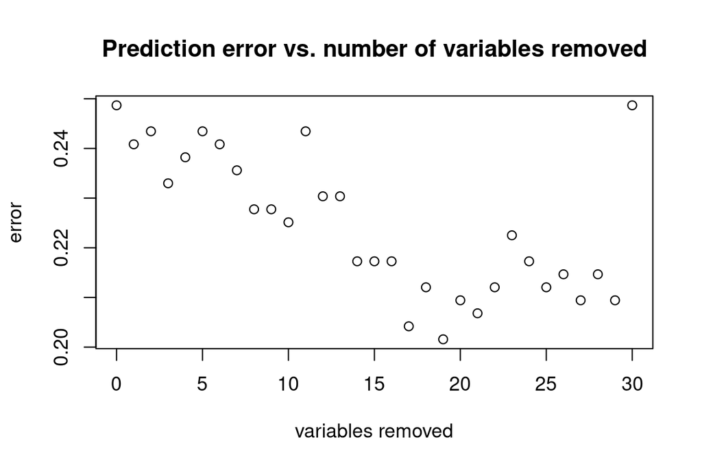

```
## integer(0)
```

```r
data = select(results, count, error)
plot(data$count, data$error,
  xlab="variables removed", ylab="error") + title(
    "Prediction error vs. number of variables removed")
```

## Course diary

### Week 1

Thoughts after the first week:

- Created IODS-project repository
- Installed R and Rstudio on Ubuntu 20.04 (Linux). Rstudio (latest 1.3.1093) keeps crashing very frequenty. R seems to work. For now I’m using Rscript to generate HTML from the .Rmd files.
- I’ve used github for years so that part was easy.
- Rstudio did not clone the github repository as I would like. It did not store the username in the cloned repository correctly. Thus manual `git pull` or `git push` did not work properly with SSH keys (it asked for git username and password). I had to tweak it manually to make SSH keys work correctly.
- The actual information on the lecture could have been presented much faster. I will probably read the information from the book/web pages/transcripts in the coming weeks rather than listening to lectures.

### Week 2

Thoughts for the second week:

- I went through the DataCamp exercises. The platform was simple and easy to use, even though this would not have been my preferred mode of learning. I would rather have read a description of the R philosophy and how main commands work and then approached it as a programming language. Now rather than learning the basics we are forced to learn snippets that may be useful in themselves, but we don’t learn to understand what options and commands really mean or what the philosophy and basic concepts are.
- It took some time to find out how to use R. I’m not a fan of its programming language syntax, but it certainly seems useful for various statistical and plotting tasks once you learn the different libraries. The challenge is that you need to become familiar with a number of libraries. In some sense python, pandas, scikit, and matplotlib still feels easier for me.
- I’ve used various types of linear regression many times in the past (least squares, Lasso, Ridge), but haven’t really looked at significance analysis and the distribution of residual errors in the past. I think that analysis may turn out to be a useful tool for me in the future. I would probably implement in Python for my machine learning applications rather than use R though.
- Rmarkdown is kind of a cool idea and nice for prototyping or coursework, but I still fail to see how to utilize it for an academic paper. The nice thing is that it leaves a trail that makes repeating the procedure easy.

### Week 3

Thoughts after the third week

- I’m becoming frustrated. I read throught the chapters of the book, but found them too general and vague, lacking precise analysis and description of the topics. Perhaps I’d prefer a more mathematical approach to the topics.
- I’m finding I really dislike R syntax and the study approach taken in the data camp exercises. They are not hard, but they are performing tasks without first gaining an understanding of the available commands and operations. We haven’t look at even the basic concepts of the *programming language* that R is, yet we are learning and memorizing snippets in the hope that they might be used for something useful. As someone with a long programming background, I’m finding this approach very frustrating, inefficient, and annoying. I’m waiting for a book on R programming to arrive.
- I do appreciate the graphics and significant testing that is easily available with R packages.
- The Super-Bonus exercise was fun.

(more chapters to be added similarly as we proceed with the course!)